# Coordinating

444 Lecture 20

Brian Weatherson

2024-03-28

## Theme for Day

Models of coordination.

Two big approaches

1. Levels approach
2. Convention approach

We’ll also mention briefly a *pure chance* approach.

# Background

1. Keynesian Beauty Contest (revision)
2. Focal Points (revision)
3. Picking and choosing
4. Rational, irrational, and arational/non-rational

> [P]rofessional investment may be likened to those newspaper competitions in which the competitors have to pick out the six prettiest faces from a hundred photographs, the prize being awarded to the competitor whose choice most nearly corresponds to the average preferences of the competitors as a whole; so that each competitor has to pick, not those faces which he himself finds prettiest, but those which he thinks likeliest to catch the fancy of the other competitors, all of whom are looking at the problem from the same point of view.

> It is not a case of choosing those which, to the best of one’s judgment, are really the prettiest, nor even those which average opinion genuinely thinks the prettiest. We have reached the third degree where we devote our intelligences to anticipating what average opinion expects the average opinion to be. And there are some, I believe, who practise the fourth, fifth and higher degrees.

## Iterations

This is an iterated model.

At every stage, someone is thinking about the results of the previous stage.

Keynes thinks it is remarkable that we might get to the fourth or fifth stage.

## Questions about the Model

1. What is the base level?
2. How many steps of iteration do real people actually do?
3. Is this even remotely the right model?

## Focal Points

Some people are playing a (more or less pure) coordination game.

In practice we observe that coordination is achieved considerably more often than we’d expect from chance.

Something about the coordinating option makes it more likely to be something we achieve coordination on.

## Focal Points in Cities

One easy way to get that coordination in the cities game is if lots of people only really know one landmark in the city.

- Sydney Opera House, Eiffel Tower, Big Ben, are all helped on this line (especially I imagine the Opera House)

## Focal Points in Cities

But sometimes something stands out not as something with first-order value, but as a natural coordination point.

- Heads in the heads/tails game, and I *think* the Bean in Chicago are like that.

## Picking and Choosing

Some helpful terminology. This is somewhat stipulative, though it’s not completely made up.

Say that someone **chooses** an option if they have (or at least take themselves to have) reason to prefer it to the other options.

And they **pick** an option if they have to make an arbitrary selection.

## Picking and Choosing

There can be in between cases.

Imagine I’m doing the groceries, and on my shopping list is *Can of diced tomatoes*.

I get to the shelf and there are hundreds of them.

I **choose** to take one from the front, not the back.

I **pick** one particular can at the front, rather than one of the other ones just as easy to reach.

## Rationality

A rational selection is where one takes the option that has the most (expected) value.

An irrational selection is where one passes up some value.

But there is an important intermediate category, called *non-rational* or *arational* selections.

## Rationality

Taking a can from the back of the shelf is **irrational**.

Taking the third can from the left rather than the fourth can from the left is **arational** or **non-rational**.

When the authors describe a choice as non-rational, they aren’t necessarilyt criticising it; they are saying it might just be arbitrary.

# Two-and-a-Half Models

## The Models

**Luck**

What Mehta et al call *primary salience*.

**Levels**

What Mehta et al sort of call *secondary salience* (though it also includes what they call tertiary etc salience).

**Convention**

What Mehta et al call *Schelling salience*.

## Luck

Here is one simple way that people could do better than chance in a coordination game.

They all have enough of the same pre-existing dispositions in favor of one of the options, and when faced with an arbitrary choice, they act on those biases.

## Sydney Again

One way to have a pre-existing disposition like this is to only have one answer that you know - maybe that was going on with Sydney.

Another is to have the rule *say first thing that pops into my head*, and have enough overlap with what these are.

## Levels Example

**Level 0**

Which option do I like the best? Would I rather be in Times Square, or the Museum of Modern Art, or by one of the lakes in Central Park?

**Level 1**

What’s my best guess as to everyone else’s answer to the Level 0 question?

**Level 2**

What’s my best guess as to everyone else’s answer to the Level 1 question?

## Levels

The theory is that people keep asking and answering as many of these questions as they can, or as they feel like, and choose the location that’s the answer to the last question they ask.

Or, more realistically, they do something inchoate that is *as if* they are stepping through these levels questions.

We’ll see some evidence for this in some experimental evidence on Tuesday.

## Keynesian Beauty Contest

That’s I think the way to read what Keynes was saying about the beauty contest.

The contestant picks the prettiest face, then tries to adjust for what other people think, and maybe for what other people think other people think, and so on.

## General Levels

You could have different ways of answering the Level 0 question.

It could just be “How likely am I to give this answer rather than that answer?”.

And that could be rational (because I like one or other better), arational (because one is salient), or even irrational (because that’s the kind of stupid thing I do).

## General Levels

On the picture I think you get in Keynes, where the Level 0 question is “Which is best?”, the levels view has a hard time with the Heads/Tails question, and the ABC question.

After all, the answer to **that** Level 0 question, in either case, is that it literally doesn’t matter; I do not care whether I write heads or tails, or ABC rather than CAB.

And this is obvious, so “Don’t care, they are all the same” is also the answer to the level 1, level 2, etc questions.

## Levels and Sub-Optimal Choices

Imagine A and B are playing the following game. Each of them has to pick a number between 1 and 1000.

If they pick the same number, they’ll get $100 each.

Exception: if they both pick 229, they’ll get $99 each.

Question: What to do?

## Levels and Sub-Optimal Choices

If the Level 0 question is “Which is best?”, it says to do anything except 229; it’s the worst option. But the other 999 options are equally good at every level.

But doesn’t it seem like 229 is actually the *right* option? It stands out, and it’s a natural thing to pick.

## Levels Approach

Whatever the level 0 question is, the levels view relies on an **asymmetry** between the person giving the answer, and the people they are mentally modelling.

They use level *n* reasoning, but they assume (perhaps implicitly) that everyone else is using level *n*-1 reasoning.

## Convention Approach

The essence of the convention approach (what Mehta et al call the *Schelling salience* approach) is that it removes this asymmetry.

Here’s how I think of it; it’s kind of a Kantian view.

The player should ask themselves this question: What is a rule for answering this question that everyone could rationally apply, and what happens if I apply that rule?

## Convention Approach

There’s no sense of levels here - everything is happening all at once.

And there is no asymmetry - each player asks whether it makes sense for everyone else to be just like them.

# Evidence

## Mehta et al on Luck

The core of the Mehta et al paper is a clever experiment designed to tease apart the Luck answer from everything else.

Strategy:

1. Ask a control group to simply answer a question.
2. Tell a treatment group that they are playing a coordination game involving that question.

If the luck view is right, you should get the two groups saying the same thing.

## Boy’s Name

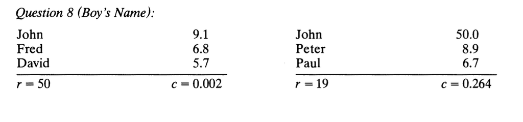

Control and treatment group for the boy’s name experiment

## Conclusion

Subjects in the coordination game are not just answering at random and happening to have the same dispositions.

On it’s own, this doesn’t say much more than that.

## Ordering

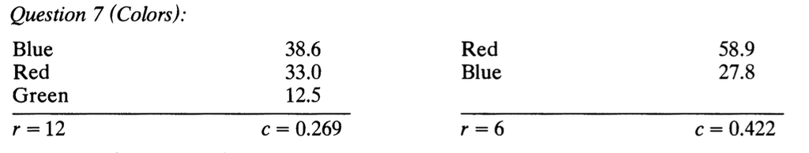

Control and treatment group for the color experiment

Should we worry that the order of the groups is different?

## Hypothesis

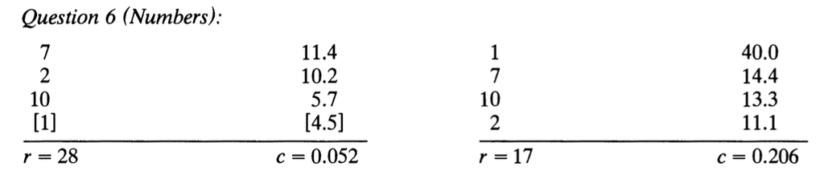

An even more dramatic case that they think is hard for the levels view to get right.

## Nagel

Ask people a version of the game we played on day one of the course:

Guess 2/3 of the average of what everyone guesses.

She also asks the guess 1/2 of the average, and guess 4/3 of the average.

## Nagel

By modern standards, this is a *terrible* experiment.

The sample consists entirely of university students, though that’s something we still do today.

But it’s just 18 people! And there doesn’t seem to have been any attempt to check they were answering seriously; in one run someone started doing bizarre things in later rounds which was enough to mess up the means.

## History

Both these papers are from the mid-1990s, and they are both in one of the most prestigious economics journals.

Neither is a fantastic experimental paper by contemporary standards, but by standards of the mid-1990s, they were good enough to be published in a top journal, and be very widely cited.

(I mean really widely cited - over 2000 times, which is a phenomenal number.)

## Nagel

I’m going to skip the 4/3 example, because it raises distinctive complications and just focus on the 1/2 and 2/3 cases.

The right answer, according to orthodox game theory, is 0 in each case.

## Nagel

One way to get that answer is by infinitely many rounds of iterated deletion.

But there’s another way to get to that answer.

It’s the only answer that you can give while thinking that everyone else gives it.

## Convention

Remember the rule for the convention approach:

- What is a rule for answering this question that everyone could rationally apply, and what happens if I apply that rule?

If you use that, you say 0. And it’s not what people say.

## Levels

On the other hand, Nagel found a bit of evidence (among her 18 subjects!!!) for something like the levels approach. Here were the three things that most struck me.

## Clustering

At the first round, there was some clustering of answers at around 50*p* and 50*p*<sup>2</sup>.

Those are the answers people who do one level, and who do two levels, would give.

## Downward Steps

Pretty systematically, after each round, people move towards the equilibrium.

And it’s not quite the Cournot, do whatever would have won on the last round approach.

## Level Consistency

OK, really grasping at straws here, but there was some weak signal that the median player was consistently doing two levels of reasoning here. They start with around 50*p*<sup>2</sup>, and they multiply by *p*<sup>2</sup> each round.

## Summary

The luck theory doesn’t seem consistent with the data at all.

## For Next Time

We’re going onto signalling, and how game theory is used to understand various phenomena about explicit and implicit communication.